# 市场观察

2016/07/04

## 一、指数估值

### (一)指数动态市盈率

核心指数成分股的动态市盈率中位数走势如下图所示：

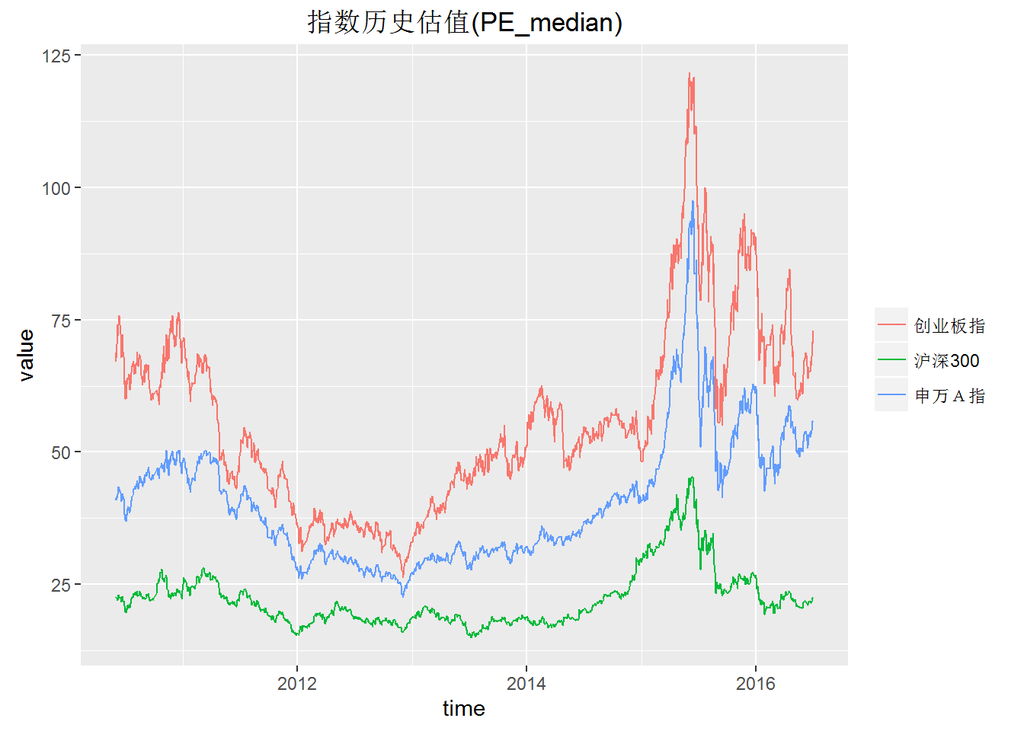

### (二)指数动态市盈率百分位

核心指数上述数据的百分位走势如下图所示：

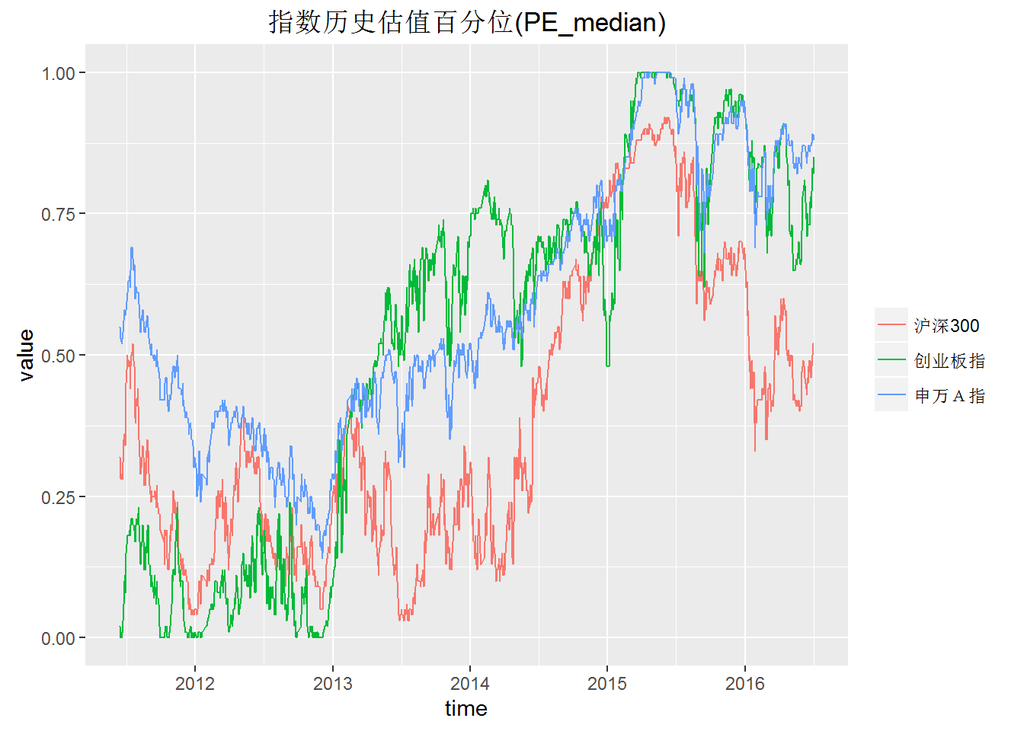

### (三)指数估值概览

纳入观察的18只指数最新的估值情况如下表：

| 日期 | 指数代码 | 指数简称 | 动态市盈率 | 上周动态市盈率 | 市盈率百分位 | 上周市盈率百分位 | 动态市净率 | 市净率百分位 |
| --- | --- | --- | --- | --- | --- | --- | --- | --- |
| 2016-07-01 | EI000979 | 大宗商品 | 44.58 | 43.36 | 0.92 | 0.90 | 2.50 | 0.45 |
| 2016-07-01 | EI000819 | 有色金属 | 62.63 | 59.49 | 0.91 | 0.90 | 4.11 | 0.86 |
| 2016-07-01 | EI801003 | 申万Ａ指 | 55.71 | 53.32 | 0.88 | 0.87 | 4.68 | 0.73 |
| 2016-07-01 | EI399959 | 军工指数 | 99.32 | 93.23 | 0.86 | 0.81 | 6.47 | 0.81 |
| 2016-07-01 | EI399006 | 创业板指 | 72.98 | 66.26 | 0.85 | 0.76 | 8.14 | 0.81 |
| 2016-07-01 | EI399005 | 中小板指P | 46.48 | 44.34 | 0.83 | 0.79 | 5.71 | 0.75 |
| 2016-07-01 | EI000805 | A股资源 | 43.09 | 42.32 | 0.82 | 0.81 | 2.41 | 0.51 |
| 2016-07-01 | EI000998 | 中证TMT | 60.71 | 57.35 | 0.79 | 0.75 | 6.09 | 0.77 |
| 2016-07-01 | EI399330 | 深证100 | 34.85 | 26.37 | 0.77 | 0.50 | 4.42 | 0.74 |
| 2016-07-01 | EI000933 | 中证医药 | 38.54 | 36.24 | 0.64 | 0.46 | 4.49 | 0.33 |
| 2016-07-01 | EI000905 | 中证500 | 39.67 | 38.09 | 0.63 | 0.59 | 3.52 | 0.56 |
| 2016-07-01 | EI801120 | 申万食品饮料 | 42.58 | 42.73 | 0.63 | 0.64 | 4.35 | 0.54 |
| 2016-07-01 | EI000808 | 医药生物 | 39.95 | 38.53 | 0.57 | 0.43 | 5.27 | 0.54 |
| 2016-07-01 | EI000300 | 沪深300 | 22.33 | 21.47 | 0.52 | 0.46 | 2.48 | 0.44 |
| 2016-07-01 | EI000827 | 中证环保 | 36.81 | 35.84 | 0.44 | 0.37 | 3.96 | 0.68 |
| 2016-07-01 | EI000932 | 中证消费 | 31.59 | 31.11 | 0.44 | 0.42 | 4.23 | 0.43 |
| 2016-07-01 | EI000934 | 中证金融 | 15.19 | 14.71 | 0.27 | 0.19 | 2.24 | 0.48 |
| 2016-07-01 | EI000016 | 上证50 | 11.90 | 11.43 | 0.08 | 0.04 | 1.46 | 0.03 |

## 二、基差

### (一)基差走势

三大股指期货隔季合约基差走势如下图：

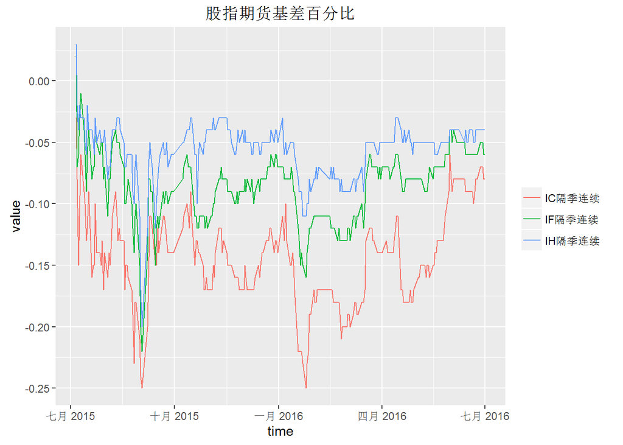

### (二)基差概况

三大股指期货连续合约基差概况如下表：

| 日期 | 合约简称 | 合约收盘价 | 基差 | 基差百分比 | 上周基差 | 上周基差百分比 |
| --- | --- | --- | --- | --- | --- | --- |
| 2016-07-01 | IH当月连续 | 2105.0 | -22.09 | -0.01 | -29.30 | -0.01 |
| 2016-07-01 | IH下月连续 | 2088.6 | -38.49 | -0.02 | -44.90 | -0.02 |
| 2016-07-01 | IH下季连续 | 2074.6 | -52.49 | -0.02 | -58.90 | -0.03 |
| 2016-07-01 | IH隔季连续 | 2040.2 | -86.89 | -0.04 | -84.30 | -0.04 |
| 2016-07-01 | IF当月连续 | 3101.0 | -53.20 | -0.02 | -63.96 | -0.02 |
| 2016-07-01 | IF下月连续 | 3062.4 | -91.80 | -0.03 | -94.16 | -0.03 |
| 2016-07-01 | IF下季连续 | 3032.0 | -122.20 | -0.04 | -120.76 | -0.04 |
| 2016-07-01 | IF隔季连续 | 2974.0 | -180.20 | -0.06 | -185.96 | -0.06 |
| 2016-07-01 | IC当月连续 | 6039.8 | -71.74 | -0.01 | -116.62 | -0.02 |
| 2016-07-01 | IC下月连续 | 5941.6 | -169.94 | -0.03 | -201.42 | -0.03 |
| 2016-07-01 | IC下季连续 | 5855.8 | -255.74 | -0.04 | -263.82 | -0.04 |
| 2016-07-01 | IC隔季连续 | 5647.0 | -464.54 | -0.08 | -472.62 | -0.08 |

## 三、套利

### (一)复牌股票套利

近两天复牌股票套利情况如下表：

| 基金代码 | 基金简称 | 基金类型 | 复牌股票简称 | 停牌时占指数比重 | 停牌日期 | 复牌日期 | 所属行业 | 停牌期间行业涨跌幅 | 停牌前场内份额 | 复牌后场内份额 | 预估最新权重 |
| --- | --- | --- | --- | --- | --- | --- | --- | --- | --- | --- | --- |
| 160218 | 国泰国证房地产 | SF | 万 科Ａ | 16.52 | 2015-12-18 | 2016-07-04 | AMAC地产 | -0.25 | 19.34 | 15.82 | 20.20 |
| 160628 | 鹏华中证800地产 | SF | 万 科Ａ | 18.45 | 2015-12-18 | 2016-07-04 | AMAC地产 | -0.25 | 2.36 | 2.24 | 19.39 |
| 165312 | 建信央视财经50 | SF | 万 科Ａ | 3.95 | 2015-12-18 | 2016-07-04 | AMAC地产 | -0.25 | 6.18 | 2.05 | 11.90 |
| 161227 | 国投瑞福100 | LOF | 万 科Ａ | 5.15 | 2015-12-18 | 2016-07-04 | AMAC地产 | -0.25 | 9.74 | 7.78 | 6.44 |
| 160814 | 长盛中证金融地产 | SF | 万 科Ａ | 3.64 | 2015-12-18 | 2016-07-04 | AMAC地产 | -0.25 | 1.34 | 0.78 | 6.25 |

### (二)定增基金跟踪

截止2016-07-04定增基金数据如下表，明细数据参见钱瀚的模板。

| 代码 | 名称 | 到期日期 | 最新净值 | 昨日收盘价 | 折溢价率 | 整体隐含折价率 | 大盘回撤0.1净值回撤 |
| --- | --- | --- | --- | --- | --- | --- | --- |
| 168101.OF | 九泰锐智 | 20200814 | 1.343 | 1.436 | 0.069 | 0.208 | -0.045 |
| 168102.OF | 九泰锐富 | 20210204 | 1.013 | 1.018 | 0.005 | 0.062 | -0.009 |
| 161222.OF | 国投瑞利 | 20160805 | 1.039 | 1.022 | -0.016 | 0.001 | -0.041 |
| 161225.OF | 国投瑞盈 | 20161119 | 0.999 | 0.994 | -0.005 | 0.070 | -0.071 |
| 501001.OF | 财通精选 | 20170101 | 1.055 | 0.982 | -0.069 | 0.030 | -0.090 |
| 501015.OF | 财通升级 | 20170908 | 1.016 | 0.954 | -0.061 | 0.075 | -0.020 |

定增基金近期的净值走势如下图：

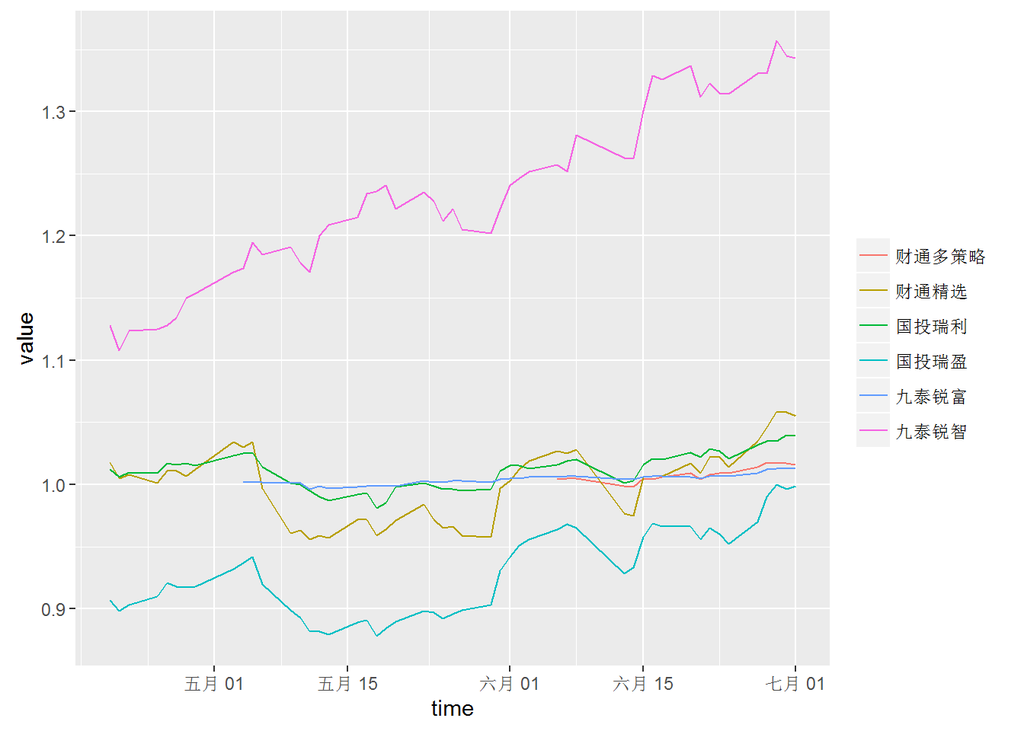

定增基金近期的折溢价走势如下图：

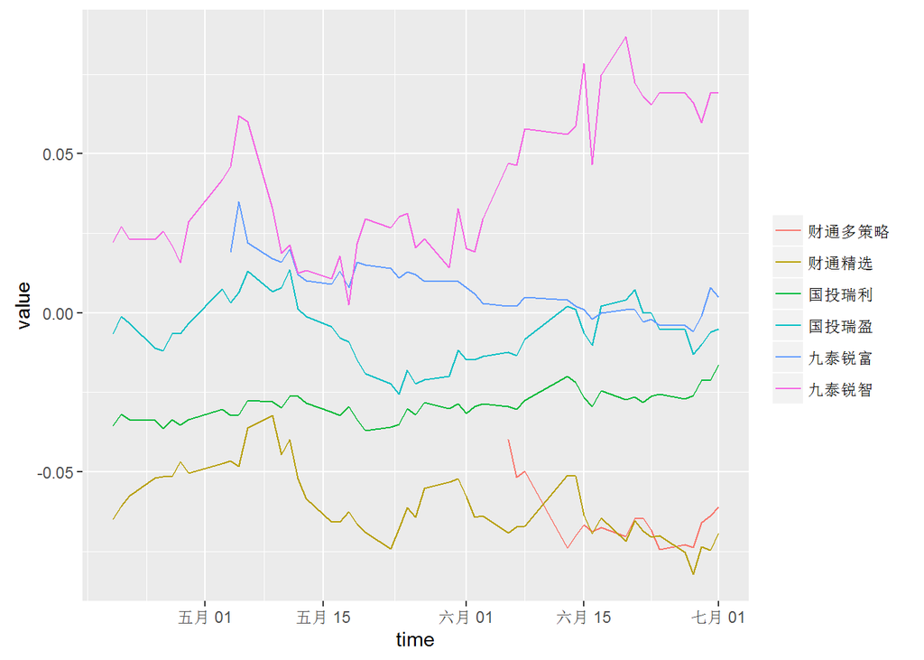

## 四、择时

### (一)大盘均线强弱指数

大盘均线强弱指数在一定程度上可以视为一个反转指标，当大盘均线得分接近8分时，预示市场接近顶部，当大盘均线得分接近0分时，预示市场接近底部。  
大盘均线强弱指数近一年来走势如下图：

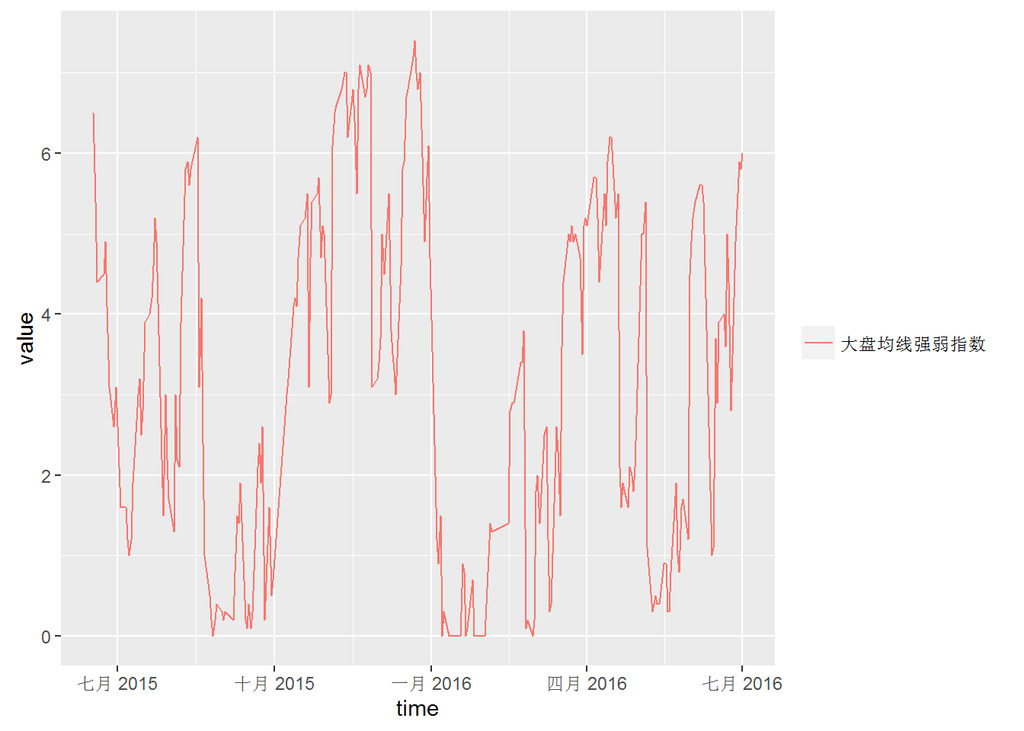

申万一级行业的最新得分及上周得分见下表：

| 日期 | 指数代码 | 指数名称 | 最新值 | 上周值 |
| --- | --- | --- | --- | --- |
| 2016-07-01 | EI801050 | 申万有色金属 | 8 | 6 |
| 2016-07-01 | EI801080 | 申万电子 | 8 | 8 |
| 2016-07-01 | EI801110 | 申万家用电器 | 8 | 5 |
| 2016-07-01 | EI801120 | 申万食品饮料 | 8 | 6 |
| 2016-07-01 | EI801880 | 申万汽车 | 8 | 5 |
| 2016-07-01 | EI801010 | 申万农林牧渔 | 7 | 0 |
| 2016-07-01 | EI801030 | 申万化工 | 7 | 5 |
| 2016-07-01 | EI801140 | 申万轻工制造 | 7 | 4 |
| 2016-07-01 | EI801150 | 申万医药生物 | 7 | 4 |
| 2016-07-01 | EI801730 | 申万电气设备 | 7 | 5 |
| 2016-07-01 | EI801740 | 申万国防军工 | 7 | 6 |
| 2016-07-01 | EI801750 | 申万计算机 | 7 | 6 |
| 2016-07-01 | EI801770 | 申万通信 | 7 | 6 |
| 2016-07-01 | EI801780 | 申万银行 | 7 | 0 |
| 2016-07-01 | EI801890 | 申万机械设备 | 7 | 5 |
| 2016-07-01 | EI801230 | 申万综合 | 6 | 2 |
| 2016-07-01 | EI801710 | 申万建筑材料 | 6 | 1 |
| 2016-07-01 | EI801790 | 申万非银金融 | 6 | 1 |
| 2016-07-01 | EI801130 | 申万纺织服装 | 5 | 0 |
| 2016-07-01 | EI801180 | 申万房地产 | 5 | 0 |
| 2016-07-01 | EI801720 | 申万建筑装饰 | 5 | 0 |
| 2016-07-01 | EI801020 | 申万采掘 | 4 | 3 |
| 2016-07-01 | EI801160 | 申万公用事业 | 4 | 0 |
| 2016-07-01 | EI801200 | 申万商业贸易 | 4 | 0 |
| 2016-07-01 | EI801210 | 申万休闲服务 | 4 | 0 |
| 2016-07-01 | EI801760 | 申万传媒 | 4 | 0 |
| 2016-07-01 | EI801040 | 申万钢铁 | 3 | 0 |
| 2016-07-01 | EI801170 | 申万交通运输 | 2 | 0 |

### (二)LLT及均线择时

LLT本质上是一个改进的单均线择时指标，较原始的均线择时延迟更低。  
择时模型和指数本身的净值走势如下图：

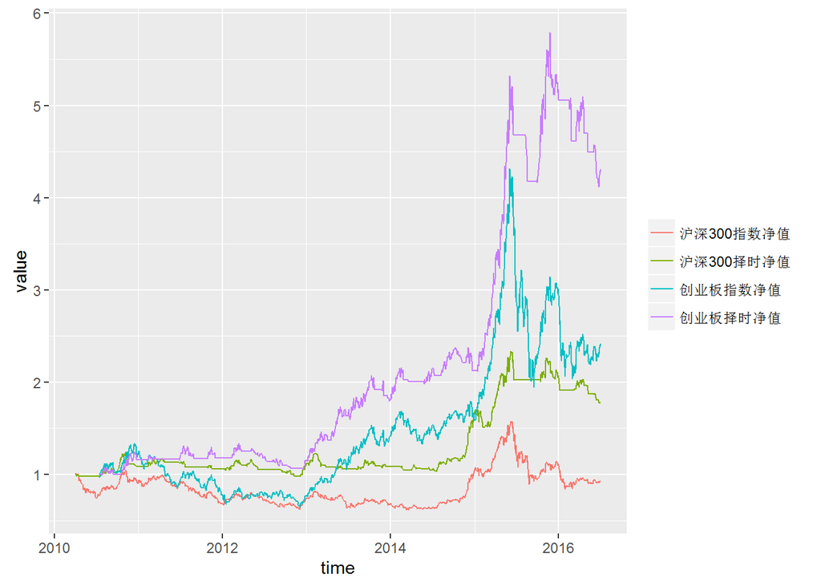

择时模型和指数的收益率统计如下表：

|  | 沪深300指 | 沪深300LLT | 创业板指 | 创业板MA |
| --- | --- | --- | --- | --- |
| 年化收益率 | -1.2 | 10.1 | 16.4 | 28.8 |
| 年化波动率 | 26.0 | 16.5 | 34.9 | 24.1 |
| 年化Sharpe值 | -4.6 | 61.1 | 47.0 | 119.5 |
| 最大回撤 | 46.7 | 24.0 | 54.9 | 28.9 |

择时模型最近10个交易日的信号如下表：

| 日期 | 沪深300收盘价 | 沪深300择时信号 | 创业板收盘价 | 创业板择时信号 |
| --- | --- | --- | --- | --- |
| 2016-06-20 | 3112.674 |  | 2119.630 | hold |
| 2016-06-21 | 3106.318 |  | 2092.001 | sell |
| 2016-06-22 | 3133.961 | buy | 2144.818 | buy |
| 2016-06-23 | 3117.317 | hold | 2137.485 | hold |
| 2016-06-24 | 3077.155 | sell | 2127.364 | hold |
| 2016-06-27 | 3120.544 |  | 2191.806 | hold |
| 2016-06-28 | 3136.401 | buy | 2216.710 | hold |
| 2016-06-29 | 3151.390 | hold | 2209.788 | hold |
| 2016-06-30 | 3153.921 | hold | 2227.790 | hold |
| 2016-07-01 | 3154.200 | hold | 2211.177 | hold |

### (三)网格交易

在经历了三轮股灾，A股逐步回归正常，在过去的一段时间呈现一个震荡的格局，如果未来没有增量信息，很可能维持震荡。结合股指期货的贴水，前期研究了一下网格交易。网格交易的结果如下图：

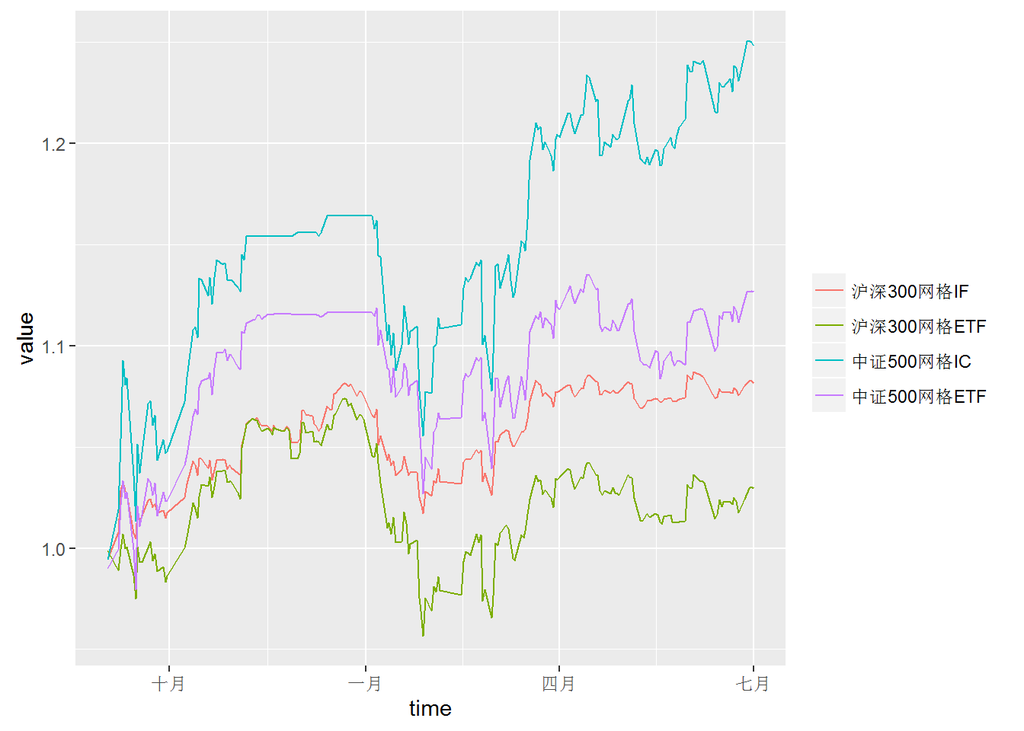

网格交易的收益统计如下表：

|  | 沪深300指数 | 沪深300网格IF | 沪深300网格ETF | 中证500指数 | 中证500网格IC | 中证500网格ETF |
| --- | --- | --- | --- | --- | --- | --- |
| 年化收益率 | -7.7 | 10.3 | 3.7 | -1.2 | 32.0 | 16.1 |
| 年化波动率 | 29.0 | 8.3 | 12.5 | 39.3 | 18.1 | 14.4 |
| 年化Sharpe值 | -26.5 | 124.7 | 29.9 | -3.0 | 177.2 | 111.7 |
| 最大回撤 | 26.4 | 5.9 | 10.9 | 33.5 | 9.4 | 8.2 |